# Prueba Técnica Profesional III Departamento de Datos no Estructurados: Modelado de Topicos con Tweets.

### Tabla de Contenido.

Nota: Puede dar click en la sección que escoja.

- Metodologia CRISP-DM
- Comprensión Empresarial
- Comprension de los Datos.
  - Importacion de Librerias y de Datos
  - Analisis Exploratorio de la Base
- Preparación de datos: Prepocesamiento de Texto.
  - Creacion Funcion de Lematizacion.
  - Creacion Funcion para la Limpieza de datos.
  - Pre-procesamiento de los datos.
  - Analisis Grafico:histogramas y Wordcloud.
- Modelacion.
  - Creacion de la Matriz de Frecuencias y el Corpus.
  - Metrica de Coherencia de Topicos.
  - Iteracion.
  - Modelado: Modelo LDA.
- Resultados y Evaluación.
  - Interpretacion de Resultados.

### Metodologia CRISP-DM

El proceso estándar de la industria cruzada para la minería de datos (CRISP-DM) es un modelo de proceso que sirve como base para un proceso de ciencia de datos. Tiene seis fases secuenciales:

**Comprensión empresarial**: ¿Qué necesita la empresa?

**Comprensión de datos**: ¿Qué datos tenemos/necesitamos? ¿Está limpio?

**Preparación de datos**: ¿Cómo organizamos los datos para el modelado?

**Modelado** – ¿Qué técnicas de modelado debemos aplicar?

**Evaluación**: ¿Qué modelo cumple mejor con los objetivos comerciales?

**Implementación**: ¿cómo acceden las partes interesadas a los resultados?

[figure not shown]

### Comprensión Empresarial.

Según Gartner, en este momento, los datos no estructurados conforman el 80-90% del total de los datos que manejan las compañías. Dentro de ellos, la información que está contenida en texto desestructurado (correos, decisiones judiciales, evaluaciones de clientes, comentarios en redes sociales, etc) representa un enorme potencial para desarrollar analítica dentro de las empresas.

Un objetivo evidente de procesamiento de texto no estructurado se encuentra en la analítica de opiniones. Mediante ella, podemos obtener información de primera mano de lo que piensan nuestros clientes, que no esté mediada por encuestas u otros elementos logísticos que conformaban en un pasado reciente la única forma de tener información estructurada acerca de lo que opinan.

### Comprension de los Datos.

Se tiene una base de datos, en la cual se tiene comentarios formulados en la red social de Twitter.

#### Importacion de Librerias y de Datos.

Las librerias mas importantes para este ejercicio son:

- nltk
- gensim
- wordcloud
- pandas

```python
import pandas as pd
import numpy as np
import glob
import os
import re
import nltk
from nltk.stem import WordNetLemmatizer
from nltk import word_tokenize
from nltk.corpus import stopwords
import string
import matplotlib.pyplot as plt
# import smart_open
smart_open.open = smart_open.smart_open
import gensim
from gensim.models import CoherenceModel, LdaModel, LsiModel, HdpModel
from gensim.models.wrappers import LdaMallet
from gensim.corpora import Dictionary
import spacy
import wordcloud
from wordcloud import WordCloud, STOPWORDS, ImageColorGenerator


from nltk.corpus import words


spanish_stopwords = stopwords.words('spanish')
english_stopwords = stopwords.words('english')
```

Python version 3.7.

Version de las librerias

- matplotlib 3.5.1
- pandas 1.3.5
- numpy 1.21.5
- nltk 3.7
- gensim 3.8.0
- spacy 2.3.5
- wordcloud 1.8.2.2

#### Importacion de los Datos.

```python
path = r'.\Datasets' # use your path

df = pd.read_csv(path + "/davivienda_tweets.csv", index_col=None)
```

### Analisis Exploratorio de la Base.

A continuación, se puede observar un resultado de las primeras filas de la base de datos.

```python
df.head()
```

|  | Unnamed: 0 | UserScreenName | UserName | Timestamp | Text | Embedded_text | Emojis | Comments | Likes | Retweets | Image link | Tweet URL |
| --- | --- | --- | --- | --- | --- | --- | --- | --- | --- | --- | --- | --- |
| 0 | 0 | Andrés Langebaek | @ALangebaek | 2021-12-01T20:43:12.000Z | Andrés Langebaek\n@ALangebaek\n·\n1 dic. | La confianza se afectó. El indicador de confia... | NaN | 1.0 | 7 | 19 | ['https://pbs.twimg.com/media/FFjL57eXMAISBnk?... | https://twitter.com/ALangebaek/status/14661458... |
| 1 | 1 | Plaza Futura | @plaza_futura | 2021-12-01T21:18:10.000Z | Plaza Futura\n@plaza_futura\n·\n1 dic. | Buscamos la accesibilidad y mejor atención en ... | ✅ ✅ ✅ ✅ ✅ | NaN | NaN | NaN | ['https://pbs.twimg.com/ext_tw_video_thumb/146... | https://twitter.com/plaza_futura/status/146615... |
| 2 | 2 | Julián Martinez | @JulianM998 | 2021-12-01T22:49:11.000Z | Julián Martinez\n@JulianM998\n·\n1 dic. | Señores \n@Davivienda\n no he podido ingresar ... | NaN | 1.0 | NaN | 1 | [] | https://twitter.com/JulianM998/status/14661775... |
| 3 | 3 | Ferchis. | @fergomezr28 | 2021-12-01T12:29:07.000Z | Ferchis.\n@fergomezr28\n·\n1 dic. | Llevo toda una semana sufriendo intento de hur... | NaN | 2.0 | 1 | 2 | [] | https://twitter.com/fergomezr28/status/1466021... |
| 4 | 4 | MirandaL2 | @MirandaSuspLo | 2021-12-01T20:52:36.000Z | MirandaL2\n@MirandaSuspLo\n·\n1 dic. | Hemos retrocedido tanto en este país con este ... | NaN | 3.0 | NaN | 8 | [] | https://twitter.com/MirandaSuspLo/status/14661... |

La base de Datos tiene 1811 filas, y 12 columnas.

```python
df.shape
```

```
(1811, 12)
```

```python
df["UserScreenName"].value_counts()[0:10]
```

```
Banco Davivienda          245
Carlos Eduardo Noguera     41
Davivienda Corredores      23
Edison Mejia                9
Juan. Manuel                8
Davivienda Escucha          7
Fabio Fernando              7
DATAiFX                     7
𝙴𝚕 𝙳𝚒𝚊𝚋𝚕𝚘                   6
ENRIQUE JOSE MARIA          6
Name: UserScreenName, dtype: int64
```

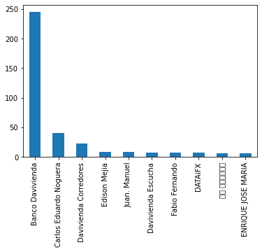

```python
df["UserScreenName"].value_counts()[0:10].plot.bar()
```

Mas del 13% de los tweets que se tienen en la base de datos, corresponde al usuario de Banco Davivienda, que tiene una representacion bastante grande, a comparacion de los otros usuarios.

```python
df["UserScreenName"].value_counts(normalize=True)[0:10]
```

```
Banco Davivienda          0.135584
Carlos Eduardo Noguera    0.022690
Davivienda Corredores     0.012728
Edison Mejia              0.004981
Juan. Manuel              0.004427
Davivienda Escucha        0.003874
Fabio Fernando            0.003874
DATAiFX                   0.003874
𝙴𝚕 𝙳𝚒𝚊𝚋𝚕𝚘                 0.003320
ENRIQUE JOSE MARIA        0.003320
Name: UserScreenName, dtype: float64
```

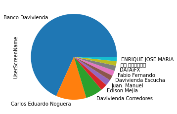

```python
df["UserScreenName"].value_counts(normalize=True)[0:10].plot.pie()
```

Existen unos valores en la variable Retweets, que no son numéricos como lo son '2,5 mil' y '1 mil', los cuales se reemplazaran a 2500 y 1000 respectivamente.

```python
df["Retweets"].unique()
```

```
array(['19', nan, '1', '2', '8', '6', '3', '4', '171', '9', '5', '11',
       '14', '10', '89', '38', '43', '18', '15', '16', '60', '123', '48',
       '7', '1 mil', '25', '13', '17', '23', '2,5 mil', '252', '12',
       '855', '20', '24'], dtype=object)
```

```python
df["Retweets"] = df["Retweets"].replace(['2,5 mil', '1 mil'], [2500, 1000])
```

Se puede observar un resumen de las únicas variables numéricas que se tiene en la base de datos, que corresponde al número de comentarios que tiene determinado tweet, “Comments”, y a la cantidad de retweets que se tiene por cada Tweet.

```python
df["Comments"] = df["Comments"].astype(float)
df["Retweets"] = df["Retweets"].astype(float)
df.iloc[:,1:].describe()
```

|  | Comments | Retweets |
| --- | --- | --- |
| count | 838.000000 | 643.000000 |
| mean | 1.511933 | 10.674961 |
| std | 3.866250 | 111.942917 |
| min | 1.000000 | 1.000000 |
| 25% | 1.000000 | 1.000000 |
| 50% | 1.000000 | 1.000000 |
| 75% | 1.000000 | 3.000000 |
| max | 87.000000 | 2500.000000 |

### Preparacion de Datos: Prepocesamiento de Texto.

Este paso se puede decir que es el mas importante, ya que permite arreglar los datos, para que queden en una forma mucho mas entendible para la maquina, se elimina redundancia, y se reduce la dimension de los datos.

### Creacion Funcion de Lematizacion

La lematización es el proceso mediante el cual las palabras de un texto que pertenecen a un mismo paradigma flexivo o derivativo son llevadas a una forma normal que representa a toda la clase. Esta forma normal, llamada lema, es típicamente la palabra utilizada como entrada en los diccionarios de lengua: el infinitivo para las conjugaciones verbales, el masculino singular para adjetivos, etc. [link](https://users.dcc.uchile.cl/~abassi/ecos/lema.html)

Para crear la función de lematización, se utiliza un conjunto de datos, en los cuales se puede obtener la forma de la palabra, y su raíz. Para descargar el conjunto de dato de lematización, en el siguiente [link](https://github.com/michmech/lemmatization-lists/blob/master/lemmatization-es.txt).

```python
lemmaDict = {}
with open(r'C:\Users\MANUEL ALEJANDRO\Downloads\lemmatization-es.txt', 'rb') as f: # datos de lematizacion
   data = f.read().decode('utf8').replace(u'\r', u'').split(u'\n') # leer los datos, en codificacion utf - 8
   data = [a.split(u'\t') for a in data]

# funcion para buscar la forma de la palabra, y su correspondiente raiz
def lemmatize(word):
   return lemmaDict.get(word, word + u'*')
```

### Creacion Funcion para la Limpieza de datos.

```python
def cleaner(word):
    #nlp = es_core_news_sm.load() # importar modulo
    list_word_clean1 = []
    list_word_clean2 = []
    lemma = []
    bigram = []

    #
    original = str(word)
    # remover links, arrobas, numerales y demas
    word = re.sub(r'((http|https)\:\/\/)?[a-zA-Z0-9\.\/\?\:@\-_=#]+\.([a-zA-Z]){2,6}([a-zA-Z0-9\.\&\/\?\:@\-_=#])*', '', str(word), flags=re.MULTILINE)
    # quitar signos de interrogacion
    word = re.sub(r'(?::|;|=)(?:-)?(?:\)|\(|D|P)', "", str(word))
    # quitar numerales
    word = re.sub(r'\#\.', '', str(word))
    # quitar separacion de texto
    word = re.sub(r'\n', '', str(word))
    # quitar comas
    word = re.sub(r',', '', str(word))
    word = re.sub(r'\-', ' ', str(word))
    # se quitan los tres puntos seguidos
    word = re.sub(r'\.{3}', ' ', str(word))
    # quitar si hay letras seguidas
    word = re.sub(r'a{2,}', 'a', str(word))
    word = re.sub(r'é{2,}', 'é', str(word))
    word = re.sub(r'i{2,}', 'i', str(word))
    word = re.sub(r'ja{2,}', 'ja', str(word))

    # eliminar espacios restantes, si quedo alguno
    word  =  re.sub(' +', ' ', str(word))
    word  = word.strip()
    word  =  re.sub('\r', '', str(word))


    # pasar todas las letras a minusculas, y eliminar stopwords en español
    for w1 in word.split(" "):
      if  w1.lower() not in spanish_stopwords:
        list_word_clean1.append(w1.lower())


    # pasar todas las letras a minusculas, y eliminar stopwords en ingles
    for w2 in list_word_clean1:
      if  w2.lower() not in english_stopwords:
        list_word_clean2.append(w2.lower())

    # se une el texto resultante
    out_text = " ".join(list_word_clean2)


    # lematizacion
    for a in list_word_clean2:
        if (a not in spanish_stopwords) and (a not in english_stopwords):
            lemma.append(lemmatize(a))
        # lemma1 = list(filter(None, lemma))

    # se encuentran todas las palabras que empiecen por @ para mencionar usuarios
    at = re.findall(r'[@]\S*', str(original))
    # se encuentran todas las palabras que empiecen por # para los hashtags
    hashtags = re.findall(r'[#]\S*', str(original))

    # la funcion devuelve las frases tratadas, la lista de palabras, los arrobas, los hashtags
    return word, list_word_clean2,out_text , at,hashtags, lemma
```

#### Pre-procesamiento de los datos.

En esta sección, se aplican las funciones creadas anteriormente, al conjunto de datos.

Se crea un dataframe, en el cual se tiene las columnas de las frases tratadas, la lista de palabras, los arrobas, los hashtags.

```python
#
word = df["Embedded_text"]


import time

start = time.time()

list_untoken = []
list_tokenize = []
list_tokenize_united = []
word_lemma = []
hashtags = []
at = []

#se itera sobre todas las filas de la columna que contiene los datos
for i in df["Embedded_text"]:
    a,b,c,d,e, f =  cleaner(word = i)
    list_untoken.append(a)
    list_tokenize.append(b)
    list_tokenize_united.append(c)
    word_lemma.append(f)
    at.append(d)
    hashtags.append(e)

# se crea un dataframe vacio, y se anexa los resultados obtenidos
df2 = pd.DataFrame()
df2["list_untoken"] = list_untoken
df2["list_tokenize"] = list_tokenize
df2["word_lemma"] = word_lemma
df2["at"] = at
df2["hashtags2"] = hashtags

end = time.time()
print(end - start)
```

```
0.8680055141448975
```

```python
# se puede obtener un vistazo del dataframe resultante
df2.head()
```

|  | list_untoken | list_tokenize | word_lemma | at | hashtags2 |
| --- | --- | --- | --- | --- | --- |
| 0 | la confianza se afectó el indicador de confian... | [confianza, afectó, indicador, confianza, davi... | [confianza*, afectó*, indicador*, confianza*, ... | [] | [] |
| 1 | buscamos la accesibilidad y mejor atención en ... | [buscamos, accesibilidad, mejor, atención, trá... | [buscamos*, accesibilidad*, mejor*, atención*,... | [] | [] |
| 2 | señores davivienda no he podido ingresar a mi ... | [señores, davivienda, podido, ingresar, app, d... | [señores*, davivienda*, podido*, ingresar*, ap... | [@Davivienda] | [] |
| 3 | llevo toda una semana sufriendo intento de hur... | [llevo, toda, semana, sufriendo, intento, hurt... | [llevo*, toda*, semana*, sufriendo*, intento*,... | [@Davivienda, @Davivienda] | [] |
| 4 | hemos retrocedido tanto en este país con este ... | [retrocedido, país, gobierno, malparidos, caje... | [retrocedido*, país*, gobierno*, malparidos*, ... | [@Davivienda] | [] |

### Analisis Grafico:histogramas y Wordcloud.

Se puede observar que se utiliza la funcion de *sklearn* del modulo *feature_extraction.text*, que se utiliza la funcion *CountVectorizer*. Esta funcion ayuda a contar la cantidad de palabras, previamente eliminando las stopwords, o palabras instrumento como se le dice en español.

```python
from sklearn.feature_extraction.text import CountVectorizer

cv = CountVectorizer(analyzer = 'word',
                lowercase = True,
                stop_words = spanish_stopwords)

words = cv.fit_transform(df2.list_untoken)

sum_words = words.sum(axis=0)

words_freq = [(word, sum_words[0, i]) for word, i in cv.vocabulary_.items()]
words_freq = sorted(words_freq, key = lambda x: x[1], reverse = True)
```

En la grafica de la parte inferior, se puede observar la frecuencia de las 30 palabras o unigramas mas usadas. Se puede observar que por mucho, las palabras *davivienda* y *respuesta* son las mas usadas en el set de datos.

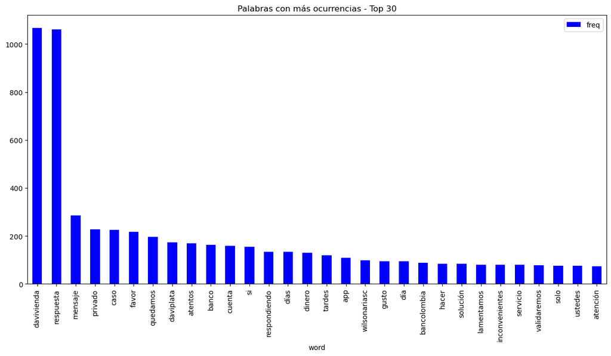

```python
frequency = pd.DataFrame(words_freq, columns=['word', 'freq'])

frequency.head(30).plot(x='word', y='freq', kind='bar', figsize=(15, 7), color = 'blue')
plt.title("Palabras con más ocurrencias - Top 30")
plt.show()
```

En la proxima grafica, se pueden observar los bigramas (composicion de dos palabras) con mas ocurrencias en el set de datos.

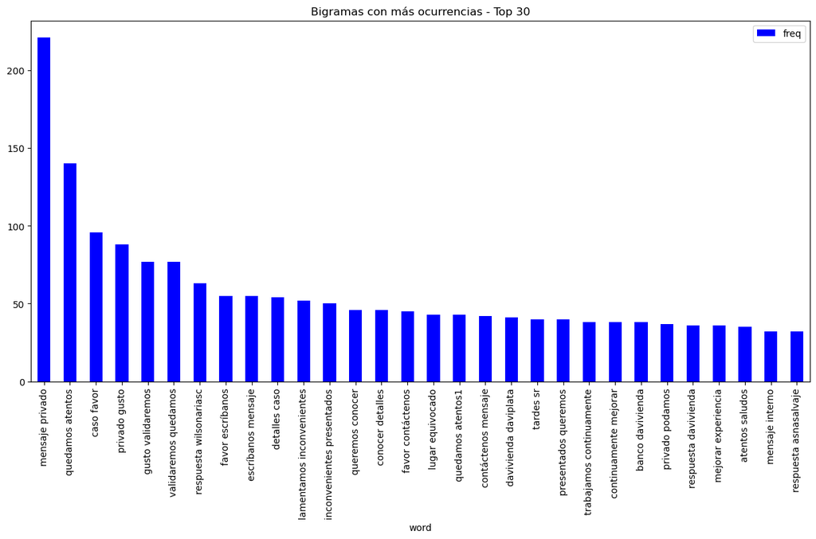

```python
cv = CountVectorizer(analyzer = 'word',
                lowercase = True,
                stop_words = spanish_stopwords,
                    ngram_range=(2,2))

words = cv.fit_transform(df2.list_untoken)

sum_words = words.sum(axis=0)

words_freq = [(word, sum_words[0, i]) for word, i in cv.vocabulary_.items()]
words_freq = sorted(words_freq, key = lambda x: x[1], reverse = True)

frequency = pd.DataFrame(words_freq, columns=['word', 'freq'])

frequency.head(30).plot(x='word', y='freq', kind='bar', figsize=(15, 7), color = 'blue')
plt.title("Bigramas con más ocurrencias - Top 30")
plt.show()
```

Por ultimo, se puede observar los trigramas (composicion de tres palabras) mas comunes.

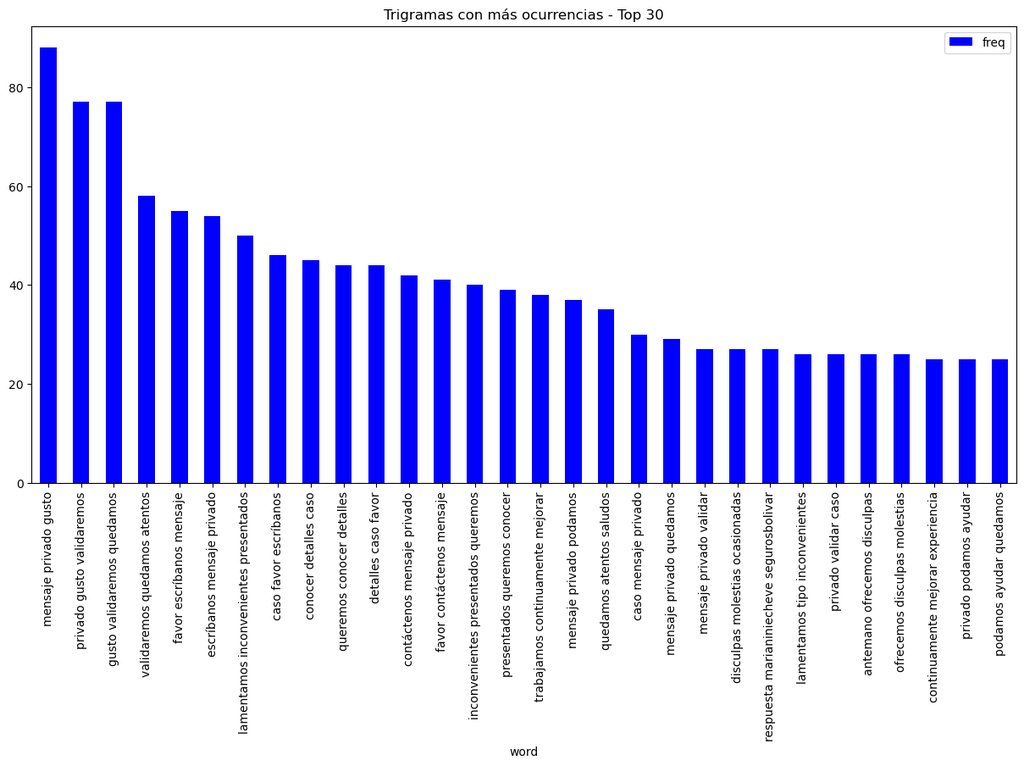

```python
cv = CountVectorizer(analyzer = 'word',
                lowercase = True,
                stop_words = spanish_stopwords,
                    ngram_range=(3,3))

words = cv.fit_transform(df2.list_untoken)

sum_words = words.sum(axis=0)

words_freq = [(word, sum_words[0, i]) for word, i in cv.vocabulary_.items()]
words_freq = sorted(words_freq, key = lambda x: x[1], reverse = True)

frequency = pd.DataFrame(words_freq, columns=['word', 'freq'])

frequency.head(30).plot(x='word', y='freq', kind='bar', figsize=(15, 7), color = 'blue')
plt.title("Trigramas con más ocurrencias - Top 30")
plt.show()
```

En el siguiente segmento de codigo, se puede observar como se crea un nube de palabras o WordCloud; se puede ver que las palabras que mas resaltan son davivienda y respuesta.

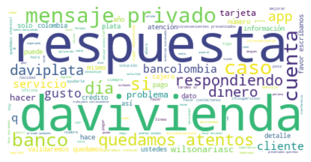

```python
text = " ".join(i for i in df2.list_untoken)

wordcloud = WordCloud(stopwords=spanish_stopwords, background_color="white").generate(text)

plt.imshow(wordcloud, interpolation='bilinear')
plt.axis("off")
plt.show()
```

### Modelacion.

Es la parte en donde se aplican los modelos que se escogieron, y que se presume pueden ayudar a responder la pregunta problema.

**Creacion de la Matriz de Frecuencias y el Corpus.**

Despues de crear algunas graficas para visualizar y poder entender mas los datos, se procede a crear el *corpus* de palabras, y la matriz de termino frecuencia.

```python
import gensim.corpora as corpora


id2word = corpora.Dictionary(df2['word_lemma'])
# Crear Corpus
texts = df2['word_lemma'].copy()
# Frecuencia de terminos y documentos.
corpus = [id2word.doc2bow(text) for text in texts]
# View
print(corpus[1:2][0][:30])
```

```
[(7, 1), (21, 1), (22, 1), (23, 1), (24, 3), (25, 1), (26, 1), (27, 1), (28, 1), (29, 1), (30, 1), (31, 1), (32, 1), (33, 1), (34, 1), (35, 1), (36, 1), (37, 1)]
```

### Metrica de Coherencia de Topicos.

En el siguiente bloque, se crea un funcion para calcular la metrica de coherencia de topicos. Entre mas alta la metrica, mejor.

**¿Qué es la coherencia de topicos?**

*"Las medidas de coherencia de topicos califican un solo tema midiendo el grado de similitud semántica entre las palabras de alto puntaje en el tema. Estas medidas ayudan a distinguir entre temas que son temas interpretables semánticamente y temas que son artefactos de inferencia estadística. Se dice que un conjunto de enunciados o hechos es coherente, si se apoyan entre sí. Por lo tanto, un conjunto de hechos coherente puede interpretarse en un contexto que cubre todos o la mayoría de los hechos."* [Fuente](https://towardsdatascience.com/evaluate-topic-model-in-python-latent-dirichlet-allocation-lda-7d57484bb5d0)

```python
# supporting function
def compute_coherence_values(corpus, dictionary, k):

    lda_model = gensim.models.LdaMulticore(corpus=corpus,
                                           id2word=id2word,
                                           num_topics=k,
                                           random_state=124)

    coherence_model_lda = CoherenceModel(model=lda_model, texts=df2['word_lemma'],
                                         dictionary=id2word, coherence='c_v')

    return coherence_model_lda.get_coherence()
```

### Iteracion.

Iteración para saber cual es la cantidad de tópicos optima, utilizando la técnica de coherencia de tópicos.

```python
import tqdm # esta libreria ayuda a saber el progreso de cualquier proceso

grid = {}
grid['Validation_Set'] = {}

# Rango de Topicos
min_topics = 2
max_topics = 30
step_size = 1
topics_range = range(min_topics, max_topics, step_size)


# Set de validacion
num_of_docs = len(corpus)
corpus_sets = [gensim.utils.ClippedCorpus(corpus, int(num_of_docs*0.75)),
               corpus]

corpus_title = ['75% Corpus', '100% Corpus']

model_results = {'Validation_Set': [],
                 'Topics': [],
                 'Coherence': []
                }

# Puede tomar un largo tiempo en correr
if 1 == 1:
    pbar = tqdm.tqdm(total=(len(topics_range)*len(corpus_title)))

    # iterar a través de corpus de validación
    for i in range(len(corpus_sets)):
        # iterar a través de la cantidad de temas
        for k in topics_range:
            # obtener la puntuación de coherencia para los parámetros dados
            cv = compute_coherence_values(corpus=corpus_sets[i], dictionary=id2word,
                                                  k=k)
            # Guardar los resultados del modelo
            model_results['Validation_Set'].append(corpus_title[i])
            model_results['Topics'].append(k)
            model_results['Coherence'].append(cv)

            pbar.update(1)
    print(pd.DataFrame(model_results))#.to_csv('lda_tuning_results2.csv', index=False)
    pbar.close()
```

```
   Validation_Set  Topics  Coherence
0      75% Corpus       2   0.266177
1      75% Corpus       3   0.273993
2      75% Corpus       4   0.291598
3      75% Corpus       5   0.340564
4      75% Corpus       6   0.342685
5      75% Corpus       7   0.349453
6      75% Corpus       8   0.323719
7      75% Corpus       9   0.336327
8      75% Corpus      10   0.340297
9      75% Corpus      11   0.358955
10     75% Corpus      12   0.338788
11     75% Corpus      13   0.361912
12     75% Corpus      14   0.346730
13     75% Corpus      15   0.355251
```

[output cut: 42 more lines]

| Validation Set | Topics | Coherence |
| --- | --- | --- |
| 100% Corpus | 2 | 0.363943 |
| 100% Corpus | 3 | 0.386662 |
| 100% Corpus | 4 | 0.420743 |
| 100% Corpus | 5 | 0.414722 |
| 100% Corpus | 6 | 0.368764 |
| 100% Corpus | 7 | 0.365602 |
| 100% Corpus | 8 | 0.331858 |
| 100% Corpus | 9 | 0.346982 |
| 100% Corpus | 10 | 0.365711 |
| 100% Corpus | 11 | 0.371927 |
| 100% Corpus | 12 | 0.349965 |
| 100% Corpus | 13 | 0.343371 |
| 100% Corpus | 14 | 0.357092 |
| 100% Corpus | 15 | 0.368883 |
| 100% Corpus | 16 | 0.380766 |
| 100% Corpus | 17 | 0.360046 |
| 100% Corpus | 18 | 0.360737 |
| 100% Corpus | 19 | 0.336970 |
| 100% Corpus | 20 | 0.348954 |
| 100% Corpus | 21 | 0.373521 |
| 100% Corpus | 22 | 0.351964 |
| 100% Corpus | 23 | 0.367800 |
| 100% Corpus | 24 | 0.350313 |
| 100% Corpus | 25 | 0.350163 |
| 100% Corpus | 26 | 0.336554 |
| 100% Corpus | 27 | 0.358122 |
| 100% Corpus | 28 | 0.354628 |
| 100% Corpus | 29 | 0.372838 |

### Modelado: Modelo LDA.

La Asignación de Dirichlet Latente (LDA por sus siglas en ingles), es uno de los algoritmos generativos más usados y con mejor desempeño en cuanto a modelado de tópicos.

Este algoritmo tiene sus bases probabilísticas en la estadística bayesiana e inferencia estadística bayesiana, pero que gracias a su gran flexibilidad, es fácilmente implementable en lenguaje de maquina y al igual que el algoritmo de Bayes Ingenuo, su asunción de independencia facilita la computación.

En la Asignación de Dirichlet Latente, se considera que cada documento, o bolsa de palabras, tiene una mezcla de varios temas que son asignados a través de este algoritmo; en esta parte se supone que la distribución de cada tema proviene de una distribución de probabilidad de Dirichlet.

[figure not shown]

### Resultados y Evaluación.

**Imprimir el resultado del modelo con 4 topicos**

```python
from gensim.models.ldamulticore import LdaMulticore
from pprint import pprint

# número de topicos
num_topics = 4
# construir modelo LDA
lda_model = LdaMulticore(corpus=corpus,id2word=id2word,num_topics=num_topics,
                         random_state=124)
# Imprimir los palabras principales de los topicos
pprint(lda_model.print_topics())
doc_lda = lda_model[corpus]
```

```
[(0,
  '0.039*"respuesta*" + 0.026*"davivienda*" + 0.011*"mensaje*" + '
  '0.011*"privado*" + 0.008*"favor*" + 0.008*"caso*" + 0.008*"quedamos*" + '
  '0.006*"atentos*" + 0.006*"cuenta*" + 0.005*"dinero*"'),
 (1,
  '0.045*"davivienda*" + 0.025*"respuesta*" + 0.010*"daviplata*" + '
  '0.006*"cuenta*" + 0.006*"banco*" + 0.005*"q*" + 0.005*"respondiendo*" + '
  '0.004*"1*" + 0.004*"si*" + 0.004*"solución*"'),
 (2,
  '0.030*"respuesta*" + 0.019*"davivienda*" + 0.015*"mensaje*" + 0.014*"caso*" '
  '+ 0.012*"quedamos*" + 0.011*"favor*" + 0.011*"privado*" + 0.010*"atentos*" '
  '+ 0.008*"lamentamos*" + 0.008*"inconvenientes*"'),
 (3,
  '0.028*"davivienda*" + 0.015*"respuesta*" + 0.005*"daviplata*" + '
  '0.005*"banco*" + 0.005*"si*" + 0.004*"app*" + 0.004*"mismo*" + '
  '0.004*"solución*" + 0.004*"respondiendo*" + 0.003*"bancolombia*"')]
```

**Imprimir el resultado del modelo con 5 topicos**

```python
# número de topicos
num_topics = 5
# construir modelo LDA
lda_model = LdaMulticore(corpus=corpus,id2word=id2word,num_topics=num_topics,
                         random_state=124)
# Imprimir los palabras principales de los topicos
pprint(lda_model.print_topics())
doc_lda = lda_model[corpus]
```

```
[(0,
  '0.036*"respuesta*" + 0.026*"davivienda*" + 0.012*"mensaje*" + '
  '0.011*"privado*" + 0.009*"favor*" + 0.008*"quedamos*" + 0.008*"caso*" + '
  '0.008*"cuenta*" + 0.007*"atentos*" + 0.006*"dinero*"'),
 (1,
  '0.045*"davivienda*" + 0.023*"respuesta*" + 0.011*"daviplata*" + '
  '0.008*"cuenta*" + 0.005*"banco*" + 0.005*"respondiendo*" + 0.004*"q*" + '
  '0.004*"1*" + 0.004*"solución*" + 0.004*"dinero*"'),
 (2,
  '0.030*"respuesta*" + 0.018*"mensaje*" + 0.017*"caso*" + 0.017*"davivienda*" '
  '+ 0.015*"quedamos*" + 0.014*"privado*" + 0.014*"favor*" + 0.013*"atentos*" '
  '+ 0.010*"lamentamos*" + 0.010*"inconvenientes*"'),
 (3,
  '0.028*"davivienda*" + 0.012*"respuesta*" + 0.007*"daviplata*" + '
  '0.005*"banco*" + 0.005*"app*" + 0.005*"si*" + 0.004*"mismo*" + '
  '0.004*"respondiendo*" + 0.004*"solución*" + 0.004*"problema*"'),
 (4,
  '0.036*"respuesta*" + 0.031*"davivienda*" + 0.005*"wilsonariasc*" + '
  '0.005*"tarjeta*" + 0.005*"días*" + 0.005*"banco*" + 0.004*"q*" + '
  '0.004*"día*" + 0.004*"servicio*" + 0.004*"mensaje*"')]
```

**Imprimir el resultado del modelo con 16 topicos**

```python
# número de topicos
num_topics = 16
# construir modelo LDA
lda_model = LdaMulticore(corpus=corpus,id2word=id2word,num_topics=num_topics,
                         random_state=124)
# Imprimir los palabras principales de los topicos
pprint(lda_model.print_topics())
doc_lda = lda_model[corpus]
```

```
[(0,
  '0.038*"respuesta*" + 0.021*"davivienda*" + 0.018*"mensaje*" + '
  '0.016*"privado*" + 0.015*"quedamos*" + 0.013*"caso*" + 0.013*"favor*" + '
  '0.011*"atentos*" + 0.009*"tardes*" + 0.007*"cuenta*"'),
 (1,
  '0.041*"davivienda*" + 0.027*"respuesta*" + 0.014*"daviplata*" + 0.007*"si*" '
  '+ 0.007*"cuenta*" + 0.006*"banco*" + 0.005*"dinero*" + 0.005*"hermano*" + '
  '0.005*"solución*" + 0.004*"problema*"'),
 (2,
  '0.033*"respuesta*" + 0.023*"caso*" + 0.023*"mensaje*" + 0.019*"atentos*" + '
  '0.019*"quedamos*" + 0.019*"privado*" + 0.018*"favor*" + 0.016*"davivienda*" '
  '+ 0.014*"lamentamos*" + 0.014*"inconvenientes*"'),
 (3,
  '0.025*"davivienda*" + 0.013*"respuesta*" + 0.008*"solución*" + '
  '0.007*"daviplata*" + 0.007*"app*" + 0.005*"banco*" + 0.005*"problema*" + '
  '0.004*"hace*" + 0.004*"así*" + 0.004*"mismo*"'),
 (4,
  '0.041*"respuesta*" + 0.028*"davivienda*" + 0.010*"q*" + 0.009*"días*" + '
  '0.007*"mensaje*" + 0.007*"servicio*" + 0.006*"si*" + 0.005*"dinero*" + '
  '0.005*"privado*" + 0.005*"caso*"'),
 (5,
  '0.033*"davivienda*" + 0.029*"respuesta*" + 0.007*"mensaje*" + '
  '0.007*"daviplata*" + 0.007*"si*" + 0.007*"cuenta*" + 0.006*"caso*" + '
  '0.006*"1*" + 0.005*"día*" + 0.005*"banco*"'),
 (6,
  '0.032*"respuesta*" + 0.030*"davivienda*" + 0.006*"mensaje*" + 0.006*"días*" '
  '+ 0.005*"app*" + 0.004*"privado*" + 0.004*"quedamos*" + 0.004*"banco*" + '
  '0.004*"asnasalvaje*" + 0.004*"dinero*"'),
 (7,
  '0.053*"davivienda*" + 0.020*"respuesta*" + 0.008*"1*" + 0.006*"cuenta*" + '
  '0.006*"2*" + 0.006*"respondiendo*" + 0.006*"lugar*" + 0.006*"wilsonariasc*" '
  '+ 0.006*"q*" + 0.005*"si*"'),
 (8,
  '0.029*"respuesta*" + 0.029*"davivienda*" + 0.007*"respondiendo*" + '
  '0.006*"2*" + 0.005*"hace*" + 0.005*"banco*" + 0.005*"favor*" + '
  '0.005*"daviplata*" + 0.005*"app*" + 0.005*"1*"'),
 (9,
  '0.026*"respuesta*" + 0.020*"davivienda*" + 0.012*"días*" + 0.010*"mensaje*" '
  '+ 0.008*"daviplata*" + 0.008*"privado*" + 0.008*"gusto*" + 0.007*"favor*" + '
  '0.007*"presentados*" + 0.007*"quedamos*"'),
```

[output cut: 10 more lines]

```
  '+ 0.007*"respondiendo*" + 0.006*"si*" + 0.005*"ustedes*" + 0.004*"2*" + '
  '0.004*"hacer*" + 0.004*"bancolombia*"'),
 (13,
  '0.026*"respuesta*" + 0.020*"davivienda*" + 0.017*"favor*" + '
  '0.017*"mensaje*" + 0.016*"privado*" + 0.014*"quedamos*" + 0.012*"atentos*" '
  '+ 0.011*"caso*" + 0.008*"lamentamos*" + 0.008*"inconvenientes*"'),
 (14,
  '0.047*"respuesta*" + 0.013*"davivienda*" + 0.007*"banco*" + '
  '0.006*"wilsonariasc*" + 0.006*"marianiniecheve*" + 0.006*"segurosbolivar*" '
  '+ 0.006*"mensaje*" + 0.005*"privado*" + 0.005*"atentos*" + '
  '0.004*"siempre*"'),
 (15,
  '0.038*"davivienda*" + 0.031*"respuesta*" + 0.008*"cuenta*" + 0.007*"app*" + '
  '0.007*"dinero*" + 0.005*"día*" + 0.005*"ustedes*" + 0.005*"2*" + '
  '0.005*"si*" + 0.004*"bancolombia*"')]
```

### Interpretacion de Resultados.

Se puede observar que las palabras que mas aparecen son “davivienda” y “respuesta”.

Se puede interpretar, que los usuarios que acuden a la red social Twitter, y mencionan al banco Davivienda, lo hacen principalmente con la intención de plantear un requerimiento, y buscando una respuesta. Se puede observar esto en los primeros tópicos que se forman al momento de imprimir el resultado de tópicos, del modelo LDA.

También se puede observar que la palabra privado aparece también en el primer tópico formado por el modelo, lo que haría referencia a que por favor se envié el requerimiento por un mensaje privado.

En cuanto al segundo tópico, se puede observar que tiene la palabra “daviplata”, “cuenta”, “problema”, lo cual se puede de interpretar con que varios usuarios están presentando inconvenientes con la plataforma de Daviplata.